# PHY141

# Lecture 1 - Basic concepts: Measurements, Uncertainty and Units

Physics is perhaps the most fundamental science. Built upon mathematical foundations it produces models and theories which can explain and predict the way that matter interacts. Within a physics department like ours there are usually scientists studying effects from the very big to the very small using both high level theory and cutting edge experiments.

Physics is at it's core a science of measurement. In this lecture we will cover key concepts related to measurement of physical quantities.

## Classical Physics

The division between classical physics and modern physics is largely historical, classical physics is used [where quantum effects and relativity can be neglected](https://upload.wikimedia.org/wikipedia/commons/5/56/Modernphysicsfields.svg_), and was largely developed before the beginning of the 20th century. This course will cover all this knowledge in two semesters (so we'll be moving fast!).

| Phy41 | Phy142 |
| --- | --- |
| Motion | Electricity |
| Fluids | Magnetism |
| Oscillations | Light |
| Waves |  |
| Heat |  |

## Units

Measurements are made with respect to a standard which defines a unit.

- How far/big? [m]
- How much? [kg]
- How much time [s]

These three quantities are the base [SI units](https://en.wikipedia.org/wiki/International_System_of_Units) for mechanics, all other units in mechanics are derived. This makes [dimensional analysis](https://en.wikipedia.org/wiki/Dimensional_analysis) a useful test of an equation, especially when calculus is taken in to account.

There are many non-SI units in common usage (especially in the USA!) . You need to know how to convert from these units to SI units and vice-versa.

## Unit prefixes

More on [Wikipedia](https://en.wikipedia.org/wiki/Metric_prefix) and in text.

| Prefix | Abbreviation | Value |
| --- | --- | --- |
| femto | *f* | 10$^{-15}$ |
| pico | *p* | 10$^{-12}$ |
| nano | *n* | 10$^{-9}$ |
| micro | $\nu$ | 10$^{-6}$ |
| mili | *m* | 10$^{-3}$ |
| centi | *c* | 10$^{-2}$ |
| deci | *d* | 10$^{-1}$ |
| kilo | *k* | 10$^{3}$ |
| mega | *M* | 10$^{6}$ |
| giga | *G* | 10$^{9}$ |
| tera | *T* | 10$^{12}$ |

## Scientific Notation

Large and small numbers are best written in scientific notation.

Examples:

0.000056 *m* = 5.6$\times 10^{-5}m$ or 5.6$\times 10^{-2}mm$

856,000 *g* = 8.56$\times 10^{5}g$ or 8,56$\times 10^{2}kg$ or 856 *kg*

In general it is not correct to give more significant figures for a number than the precision to which you know it. However **you should not round off numbers too early in a calculation, as this can affect the accuracy of the final answer.**

```python
# Scientific notation in Python
scientific_notation = "{:.2e}".format(0.000056) # (:.2e) scientific notation with two digist
print(scientific_notation)
scientific_notation = "{:.2e}".format(856000)
print(scientific_notation)

# Life of Universe in seconds, in years ~13 billion years, 13e9 years
print("Life of the universe is {:.2e} s".format(13e9*60*60*24*365))
```

```
5.60e-05
8.56e+05
Life of the universe is 4.10e+17 s
```

## Accuracy and Precission

While the words accuracy and precision sound like they refer to similar things their meanings in physics are actually slightly different.

Precision refers to how well a quantity can be determined. This determination of this quantity be the result of multiple independent measurements, which presumably would improve the precision, but when we talk of precision we are not considering how the value of the quantity compares to a “known” or “established” value.

Accuracy, on the other hand, does make this comparison. The accuracy of a measurement refers to how well a measured value agrees with a a “known” or “established” value.

### Examples:

**Precision**

- I measure the length of an object with a ruler and I am confident that my measured value, in meters, is correct to 3 decimal places. I can now say that my measurement has a precision of 1mm.

**Accuracy**

- The object I measured is actually a standard length whose length is known absolutely (because it's a standard!), the difference between my measured value and the known correct value is the accuracy of my measurement.

## Error and Unicertainty

The **precision** to which we can measure something is limited by experimental factors, leading to **uncertainty**.

The deviation of a measurement from the “correct” value is termed the error, so error is a measurement of how inaccurate our results are. There are two general types of errors.

**Systematic Errors**

- A error that is constant from one measurement to another, for example, an incorrectly marked ruler would always make the same mistake measuring something as either bigger or smaller than it actually is every time. These errors can be quite difficult to eliminate!

**Random Errors**

- Random errors in your measurement occur statistically, ie. they deviate from the correct value in both directions. These can be reduced by repeated measurement.

But here is where it gets confusing… When you estimate the uncertainty of your measurement, as you will do frequently in the lab component of this course, you should consider the possible sources of error that contribute to the uncertainty. This way if there are large sources of error in your experiment, you will have a large uncertainty which will not exclude the accurate value of the quantity you are trying to measure.

### Example of systematic error

An easily accessible standard is the [offical US time](http://www.time.gov/timezone.cgi?Eastern/d/-5/java) kept by NIST. This can be compared to a watch to evaluate the systematic error in the time we should consider if we were to use it to time an experiment. This would probably only concern us if we needed to know the actual time that an event occurred at, rather than the difference in time for two events measured with the same watch.

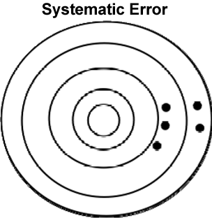

### Example of random error

A very simple example is our blood pressure. Even if someone is healthy, it is normal that their blood pressure does not remain exactly the same every time it is measured. If several measurements of blood pressure were taken over time, some would be higher and some would be lower. The reason for this random error is to be expected because of variation in normal processes in the body and in the way that the measuring device works. If error is truly random, and if we take enough measurements, then it is still possible to get a good estimate of what we are measuring. However, if random error is large, then our measurements will be unpredictable, inconsistent and they will not represent the true value of what we are measuring.

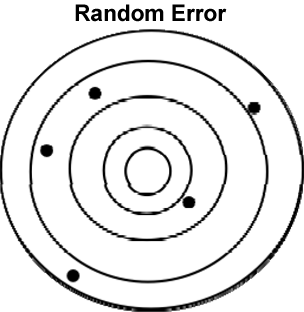

## Averaging and Standard Deviation

When a leading cause of uncertainty in our measurement is random error we can lower the uncertainty in our measurement by repeated measurement and averaging (if the main sources of error are random). If we can assume that our measurements are governed by a [typical statistical distribution](http://upload.wikimedia.org/wikipedia/commons/thumb/8/8c/Standard_deviation_diagram.svg/1000px-Standard_deviation_diagram.svg.png) then the [standard deviation](https://en.wikipedia.org/wiki/Standard_deviation) becomes a useful measurement of the variance of our data.

Average of N measurements: $\overline{t}=\frac {\sum t_{i}}{N} $

Deviation, or, how much does an individual measurement differ from the mean value: $t_{i}-\overline{t}$

Standard deviation:$\sigma_t=\sqrt{\frac {\sum (t_{i}-\overline{t})^2}{(N-1)}}$

Standard deviation of the mean, or Standard Error: $\sigma_{\overline{t}}=\sqrt{\frac {\sum (t_{i}-\overline{t})^2}{N(N-1)}}$

## Propagation of uncertainty

Very often we need to make more than one measurement, or manipulate a measured quantity in an equation to find the quantity we really want. In these cases we need to **propagate** uncertainty. If the quantity we want to know is $f(x)$ and there is some variation in the measured quantity $x$ we can deduce the variation in $f(x)$ using calculus.

$\delta f = \frac{df}{dx}\delta x$

and then take the average of our mutliple variations

$\langle \delta f^{2} \rangle = (\frac{df}{dx})^2\langle \delta x^{2} \rangle$

Taking the square root gives us the relationship we are looking for

$\sqrt{\langle \delta f^{2} \rangle} = |\frac{df}{dx}|\sqrt{\langle \delta x^{2} \rangle} \rightarrow \sigma_f = |\frac{df}{dx}|\sigma_x$

### Propagation with two variables

If $f(x,y)$ then $\delta f = \frac{\partial f}{\partial x}\delta x + \frac{\partial f}{\partial y}\delta y$

Now $\delta f^{2} = (\frac{\partial f}{\partial x})^2\delta x^2 + (\frac{\partial f}{\partial y})^2\delta y^2 + \frac{\partial f}{\partial x}\frac{\partial f}{\partial y}\delta x \delta y$

And $\langle \delta f^{2} \rangle = (\frac{\partial f}{\partial x})^2\langle\delta x^2 \rangle + (\frac{\partial f}{\partial y})^2\langle\delta y^2 \rangle + \frac{\partial f}{\partial x}\frac{\partial f}{\partial y}\langle\delta x \delta y\rangle$

**Does the variation in $x$ affect the variation in $y$?**

If not we can say that these variables are uncorrelated and that $\langle\delta x \delta y\rangle = 0$, which leads us to

$\sigma_f = \sqrt{(\frac{\partial f}{\partial x})^2\sigma_x^2 + (\frac{\partial f}{\partial y})^2\sigma_y^2}$

### Some propagation rules

These are useful rules to remember that come as a result of the calculus we did before.

if $S=A\pm B$ then $\sigma_S=\sqrt{((\sigma_A)^2+(\sigma_B)^2)}$

if $S=A\times B$ **or** $\frac{A}{B}$ then $\large \frac{\sigma_S}{S}=\sqrt{((\frac{\sigma_A}{A})^2+(\frac{\sigma_B}{B})^2)}$

if $S=A^n$ then $\large \frac{\sigma_S}{S}=|n|\times \frac{\sigma_A}{A}$

## Why is error and uncertainty so important?

An accurate estimate of the uncertainty in an experiment is the only way to determine whether an experiment is **consistent** or **inconsistent** with a theory.

If the theoretical prediction lies within the estimate of the uncertainty of the experiment then we can say the theory is consistent with the experiment. Another way of stating this would be that the measured value is consistent with the theoretical one if the error is less than the uncertainty. However, if the uncertainty is very large this this may be a meaningless statement! If we estimate the uncertainty to be smaller than it really is we may discard a valid theory (and perhaps an important discovery).

Our aim is therefore always to accurately estimate the uncertainty of our results and strive to improve it!

## Fermi Problems

From [wikipedia](https://en.wikipedia.org/wiki/Fermi_problem): In physics or engineering education, a Fermi problem, Fermi quiz, Fermi question, Fermi estimate, order-of-magnitude problem, order-of-magnitude estimate, or order estimation is an estimation problem designed to teach dimensional analysis or approximation of extreme scientific calculations, and such a problem is usually a back-of-the-envelope calculation. The estimation technique is named after physicist Enrico Fermi as he was known for his ability to make good approximate calculations with little or no actual data. Fermi problems typically involve making justified guesses about quantities and their variance or lower and upper bounds. In some cases, order-of-magnitude estimates can also be derived using dimensional analysis.

### Example:

When you take a single breath, how many molecules of gas you intake would have come from the dying breath of Caesar?" For the sake of simplicity, we can assume that the molecules which Caesar exhaled in his last breath have diffused evenly to the whole atmosphere, and these molecules were not absorbed by the ocean or plants for thousands of years. Although these are not valid assumptions, they can help us forget about the complexity of the real world, and to make elementary estimations in the simplest way.

```python
import numpy as np
R_earth=6400 #Km
h_atm = 50 #Km
V_lung = 1 #l
V_mol = 22.4 #l/mol
Na = 6.02e23 # molecules/mol
V_atm = 4*np.pi*(R_earth*1e3)**2*50e3 #m^3

l2m3 = 1e-3 #m^3/l

NmolInBreadth1 = Na/V_mol #molec/l

Nmol1 = NmolInBreadth1/(V_atm/(V_lung*l2m3))
print('answer 1 is {:.2e}'.format(Nmol1))
rho = 1.2 #kg/m^3 Density of air at surface of earth
uma = 1.6e-27 #Kg/u
mn2 = 2*14*uma
NmolInBreadth2 = (V_lung*l2m3*rho)/mn2

Nmol2 = NmolInBreadth2/(V_atm/(V_lung*l2m3))
print('answer 2 is {:.2e}'.format(Nmol2))
```

```
answer 1 is 1.04e+00
answer 2 is 1.04e+00
```